# Guide_RNA_Analysis_SRG1_in_yeast

Catherine Taylor

2024-10-31

```r
# Guide RNA Analysis and validation for CRISPR knock out gene SRG1 in Saccharomyces cerevisiae (yeast).

# This analysis aims to identify the optimal guide RNA sequence among the top four ranked guides, focusing on specificity, efficiency, and off-target effects.

# Load necessary libraries
install.packages("ggcorrplot")
library(readr)
library(ggcorrplot)
library(tidyr)
library(readxl)      # For reading Excel files
library(dplyr)       # For data manipulation
library(ggplot2)     # For data visualisation
library(knitr)       # For rendering tables in Markdown
library(kableExtra)  # For enhanced table aesthetics
library(gridExtra)   # For multi-plot layout
# Load the data
RNA_Seq <- read_csv("Project_4_Guide_RNA_Analysis_SRG1_in_yeast.xlsx - Sheet1.csv")
# Display the data table
kable(RNA_Seq) %>%
  kable_styling(bootstrap_options = c("striped", "hover"), full_width = FALSE)
```

Rank

Target Sequence

Genomic Location

Strand

GC Content (%)

Self-Complementarity

MM0 (Exact Match)

MM1

MM2

MM3

MIT Specificity Score

CFD Specificity Score

Doench ’16 Efficiency

Mor.-Mateos Efficiency

Doench RuleSet3 Score

Off-Targets

Restriction Enzymes

1

CAACAAGCTATGAATATGAGCGG

chrV:322725-322747

35

0

0

0

0

0

100

100

69

35

39

0

None

2

ACTCACAAATGGAATTCAAGGGG

chrV:322335-322357

35

0

0

0

0

0

98

100

62

28

26

2 (HGH1, TPK3)

AgsI

3

CCCGTGCAGGGTTTTCTGAGCGG

chrV:322467-322489

60

0

0

0

0

0

99

100

62

50

-91

2 (intergenic: HSP82-YAR1, YJU3-MBR1)

BstDEI, Hpy188I

```r
# Summary statistics of the dataset
summary(RNA_Seq)
```

```
##       Rank     Target Sequence    Genomic Location      Strand
##  Min.   :1.0   Length:3           Length:3           Length:3
##  1st Qu.:1.5   Class :character   Class :character   Class :character
##  Median :2.0   Mode  :character   Mode  :character   Mode  :character
##  Mean   :2.0
##  3rd Qu.:2.5
##  Max.   :3.0
##  GC Content (%)  Self-Complementarity MM0 (Exact Match)      MM1         MM2
##  Min.   :35.00   Min.   :0            Min.   :0         Min.   :0   Min.   :0
##  1st Qu.:35.00   1st Qu.:0            1st Qu.:0         1st Qu.:0   1st Qu.:0
##  Median :35.00   Median :0            Median :0         Median :0   Median :0
##  Mean   :43.33   Mean   :0            Mean   :0         Mean   :0   Mean   :0
##  3rd Qu.:47.50   3rd Qu.:0            3rd Qu.:0         3rd Qu.:0   3rd Qu.:0
##  Max.   :60.00   Max.   :0            Max.   :0         Max.   :0   Max.   :0
##       MM3    MIT Specificity Score CFD Specificity Score Doench '16 Efficiency
##  Min.   :0   Min.   : 98.0         Min.   :100           Min.   :62.00
##  1st Qu.:0   1st Qu.: 98.5         1st Qu.:100           1st Qu.:62.00
##  Median :0   Median : 99.0         Median :100           Median :62.00
##  Mean   :0   Mean   : 99.0         Mean   :100           Mean   :64.33
##  3rd Qu.:0   3rd Qu.: 99.5         3rd Qu.:100           3rd Qu.:65.50
##  Max.   :0   Max.   :100.0         Max.   :100           Max.   :69.00
##  Mor.-Mateos Efficiency Doench RuleSet3 Score Off-Targets
##  Min.   :28.00          Min.   :-91.000       Length:3
##  1st Qu.:31.50          1st Qu.:-32.500       Class :character
##  Median :35.00          Median : 26.000       Mode  :character
##  Mean   :37.67          Mean   : -8.667
##  3rd Qu.:42.50          3rd Qu.: 32.500
##  Max.   :50.00          Max.   : 39.000
##  Restriction Enzymes
##  Length:3
##  Class :character
##  Mode  :character
##
##
##
```

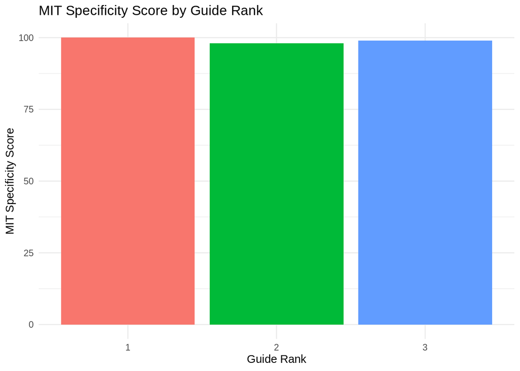

```r
# Visualising MIT and CFD Specificity Scores
ggplot(RNA_Seq, aes(x = factor(Rank), y = `MIT Specificity Score`, fill = factor(Rank))) +
  geom_bar(stat = "identity") +
  labs(title = "MIT Specificity Score by Guide Rank", x = "Guide Rank", y = "MIT Specificity Score") +
  theme_minimal() +
  theme(legend.position = "none")
```

##### Figure 1 is a bar chart that displays the MIT Specificity Scores of guide RNAs (gRNAs) ranked 1 to 3, measuring their precision for targeting the SRG1 gene in yeast during CRISPR-Cas9 experiments. The x-axis represents the guide rank, categorized from 1 to 3 based on their suitability for gene targeting. The y-axis shows the MIT Specificity Score, which ranges from 0 to 100, where a higher score indicates greater specificity and reduced likelihood of off-target effects. Guide Rank 1 achieves the maximum score of 100, representing perfect precision, while Ranks 2 and 3 also have high scores, slightly below 100, confirming their substantial targeting accuracy.

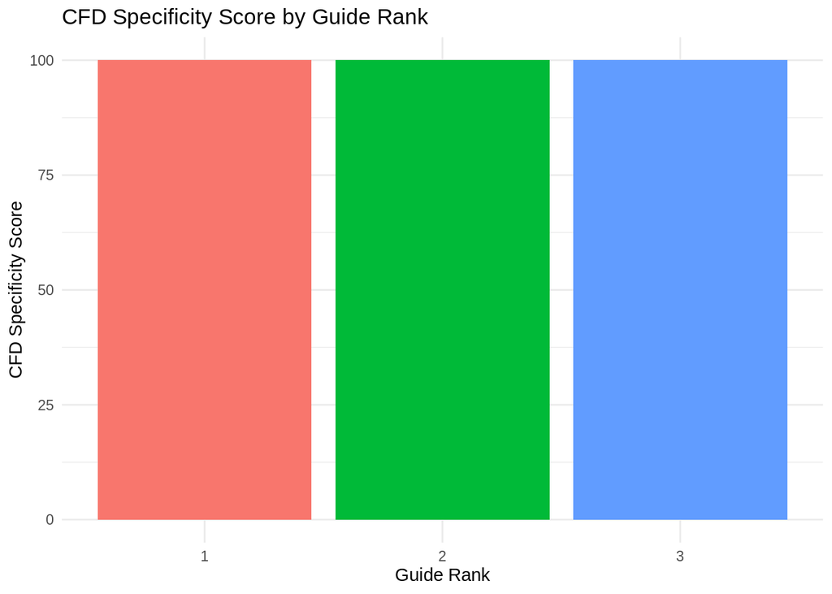

```r
ggplot(RNA_Seq, aes(x = factor(Rank), y = `CFD Specificity Score`, fill = factor(Rank))) +
  geom_bar(stat = "identity") +
  labs(title = "CFD Specificity Score by Guide Rank", x = "Guide Rank", y = "CFD Specificity Score") +
  theme_minimal() +
  theme(legend.position = "none")
```

##### Figure 2 bar chart illustrates the CFD Specificity Scores for guide RNAs (gRNAs) ranked 1 to 3, evaluated for their precision in targeting the SRG1 gene in yeast for CRISPR-Cas9 experiments. The x-axis represents the guide rank, ranging from 1 to 3, while the y-axis shows the CFD (Cutting Frequency Determination) Specificity Score, scaled from 0 to 100. The CFD score quantifies the likelihood of accurate binding to the intended target sequence while minimising off-target binding events. In this chart, all three guides achieve the maximum CFD score of 100, indicating perfect specificity.

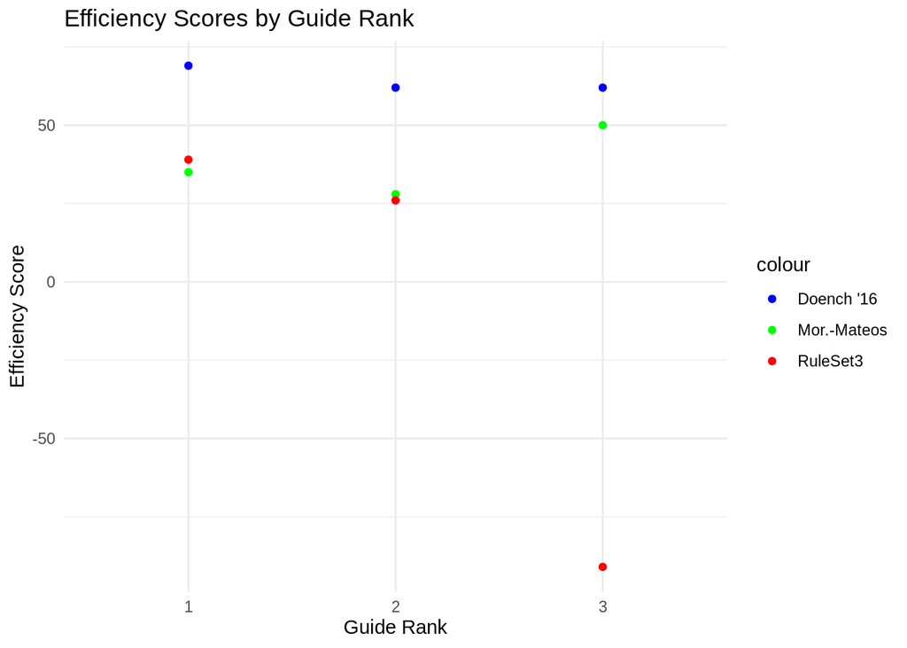

```r
# Efficiency scores comparison using a scatter plot
ggplot(RNA_Seq, aes(x = factor(Rank))) +
  geom_point(aes(y = `Doench '16 Efficiency`, color = "Doench '16")) +
  geom_point(aes(y = `Mor.-Mateos Efficiency`, color = "Mor.-Mateos")) +
  geom_point(aes(y = `Doench RuleSet3 Score`, color = "RuleSet3")) +
  labs(title = "Efficiency Scores by Guide Rank", x = "Guide Rank", y = "Efficiency Score") +
  scale_color_manual(values = c("Doench '16" = "blue", "Mor.-Mateos" = "green", "RuleSet3" = "red")) +
  theme_minimal()
```

```r
# Table summarizing off-targets for each guide
off_target_summary <- RNA_Seq %>%
  select(Rank, `Off-Targets`)

kable(off_target_summary, col.names = c("Rank", "Off-Target Summary")) %>%
  kable_styling(bootstrap_options = c("striped", "hover"), full_width = FALSE)
```

| Rank | Off-Target Summary |
| --- | --- |
| 1 | 0 |
| 2 | 2 (HGH1, TPK3) |
| 3 | 2 (intergenic: HSP82-YAR1, YJU3-MBR1) |

##### Table 1 summarises the off-target analysis for guide RNAs (gRNAs) ranked 1 to 3, targeting the SRG1 gene in yeast. Rank 1 demonstrates perfect specificity with zero off-targets, making it the most precise choice for CRISPR-Cas9-mediated knockout experiments. Rank 2, while highly specific, has two off-targets located in exonic regions of the HGH1 and TPK3 genes, which may pose a risk of unintended gene disruptions. Rank 3 also shows two off-targets located in intergenic regions between HSP82-YAR1 and YJU3-MBR1.

```r
# Create a correlation matrix for specificity and efficiency scores
cor_matrix <- cor(RNA_Seq %>%
  select(`MIT Specificity Score`, `CFD Specificity Score`, `Doench '16 Efficiency`, `Mor.-Mateos Efficiency`, `Doench RuleSet3 Score`))
```

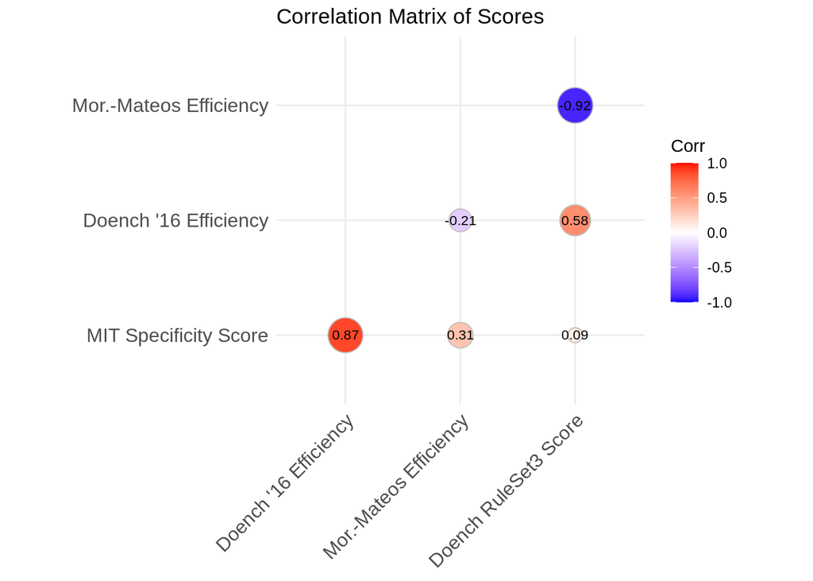

```r
# Visualize the correlation matrix
ggcorrplot(cor_matrix, method = "circle", type = "lower", lab = TRUE, lab_size = 3, title = "Correlation Matrix of Scores")
```

##### Figure 4 correlation matrix visualises the relationships between various scoring metrics used to evaluate guide RNAs (gRNAs) for targeting the SRG1 gene in yeast. The x-axis and y-axis represent the scores: Doench ’16 Efficiency, Mor.-Mateos Efficiency, MIT Specificity Score, and Doench RuleSet3 Score, with their pairwise correlations indicated in the cells. The colour gradient signifies the strength and direction of the correlation, ranging from blue for strong negative correlations (-1.0) to red for strong positive correlations (+1.0). Key observations include a strong positive correlation (0.87) between the MIT Specificity Score and Doench ’16 Efficiency, suggesting that guides with high specificity also tend to have higher Efficiency.

```r
# Identify the best guide based on specificity and efficiency
best_guide <- RNA_Seq %>%
  filter(`MIT Specificity Score` >= 98 & `CFD Specificity Score` == 100 & `Doench '16 Efficiency` > 60 & `Off-Targets` == "0")

# Display the best guide in a formatted table
kable(best_guide, col.names = c("Rank", "Target Sequence", "Genomic Location", "Strand", "GC Content (%)",
                                "Self-Complementarity", "MM0", "MM1", "MM2", "MM3",
                                "MIT Specificity Score", "CFD Specificity Score",
                                "Doench '16 Efficiency", "Mor.-Mateos Efficiency",
                                "Doench RuleSet3 Score", "Off-Targets", "Restriction Enzymes")) %>%
  kable_styling(bootstrap_options = c("striped", "hover"), full_width = FALSE)
```

Rank

Target Sequence

Genomic Location

Strand

GC Content (%)

Self-Complementarity

MM0

MM1

MM2

MM3

MIT Specificity Score

CFD Specificity Score

Doench ’16 Efficiency

Mor.-Mateos Efficiency

Doench RuleSet3 Score

Off-Targets

Restriction Enzymes

1

CAACAAGCTATGAATATGAGCGG

chrV:322725-322747

35

0

0

0

0

0

100

100

69

35

39

0

None

```r
# Conclusion: Based on the analysis, the guide RNA with Rank 1 is the optimal choice due to its high specificity, strong efficiency, and absence of off-target effects.
```

##### Table 2 identifies the optimal guide RNA for targeting the SRG1 gene in yeast, summarised. Rank 1 is the most suitable choice due to its exceptional performance across multiple evaluation metrics. Its Target Sequence, CAACAAGCTATGAATATGAGCGG, is located on chromosome V at position 322725–322747 on the forward strand with a GC content of 35%. The guide shows no self-complementarity or mismatches (MM0–MM3), ensuring minimal unintended interactions. Importantly, it achieves a perfect MIT Specificity Score (100) and CFD Specificity Score (100), guaranteeing high precision and specificity in the yeast genome. The guide’s Doench ’16 Efficiency Score is a robust 69, coupled with a moderate Mor.-Mateos Efficiency Score of 35 and a Doench RuleSet3 Score of 39, collectively indicating strong potential for effective gene knockout. Furthermore, this guide has zero off-targets and no associated restriction enzyme conflicts.